# Direction - Y (wtccc_crohn); I (Prins_igf1)

Yanyu Liang

February 23, 2018

# Read data

```r
source("scripts/myRLib.R")
xt <- read.table("output-direction_XT_YI/Prins_igf1__wtccc_crohn__wtccc_ctrl/xt.assoc.logistic",
    header = T)
xt$SNP <- as.character(xt$SNP)
xt <- xt[order(xt$SNP), ]
yi <- read.table("output-direction_XT_YI/Prins_igf1__wtccc_crohn__wtccc_ctrl/yi.logistic.assoc",
    header = T)
xtyi.files <- strsplit("output-direction_XT_YI/Prins_igf1__wtccc_crohn__wtccc_ctrl/xtyi_LDpred_p1.0000e+00.assoc.logistic:output-direction_XT_YI/Prins_igf1__wtccc_crohn__wtccc_ctrl/xtyi_LDpred_p3.0000e-01.assoc.logistic:output-direction_XT_YI/Prins_igf1__wtccc_crohn__wtccc_ctrl/xtyi_LDpred_p1.0000e-01.assoc.logistic:output-direction_XT_YI/Prins_igf1__wtccc_crohn__wtccc_ctrl/xtyi_LDpred_p3.0000e-02.assoc.logistic:output-direction_XT_YI/Prins_igf1__wtccc_crohn__wtccc_ctrl/xtyi_LDpred_p1.0000e-02.assoc.logistic:output-direction_XT_YI/Prins_igf1__wtccc_crohn__wtccc_ctrl/xtyi_LDpred_p3.0000e-03.assoc.logistic:output-direction_XT_YI/Prins_igf1__wtccc_crohn__wtccc_ctrl/xtyi_LDpred_p1.0000e-03.assoc.logistic:output-direction_XT_YI/Prins_igf1__wtccc_crohn__wtccc_ctrl/xtyi_LDpred_p3.0000e-04.assoc.logistic:output-direction_XT_YI/Prins_igf1__wtccc_crohn__wtccc_ctrl/xtyi_LDpred_p1.0000e-04.assoc.logistic",
    ":")[[1]]
ps <- strsplit("1:0.3:0.1:0.03:0.01:0.003:0.001:0.0003:0.0001",
    ":")[[1]]
```

# Plots

```r
for (i in 1:length(xtyi.files)) {
    xtyi <- read.table(xtyi.files[i], header = T)
    xtyi$SNP <- as.character(xtyi$SNP)
    xtyi <- xtyi[order(xtyi$SNP), ]
    p <- ps[i]
    cat("##", "Cutoff =", p, "\n")
    cat("\n")
    cat("\n")
    cat("Filename is", as.character(yi[i, 1]))
    cat("\n")
    pander(yi[i, 2:ncol(yi)])
    qqplot(-log10((1:length(xt$P))/length(xt$P)), -log10(xt$P),
        main = "QQplot - Gi: Y ~ Gi", xlab = "-log10 expected pval",
        ylab = "-log10 observed pval")
    abline(a = 0, b = 1, col = "red")
    qqplot(-log10((1:length(xtyi[xtyi$TEST == "ADD", "P"]))/length(xtyi[xtyi$TEST ==
        "ADD", "P"])), -log10(xtyi[xtyi$TEST == "ADD", "P"]),
        main = "QQplot - Gi: Y ~ Gi + I", xlab = "-log10 expected pval",
        ylab = "-log10 observed pval")
    abline(a = 0, b = 1, col = "red")
    hist(log(xtyi[xtyi$TEST == "PRS", "OR"]), main = "Hist - I: Y ~ Gi + I",
        xlab = "OR")
    abline(v = yi[i, "prs.estmate"], col = "red")
    abline(v = yi[i, "prs.estmate"] - yi[i, "prs.std"], col = "red")
    abline(v = yi[i, "prs.estmate"] + yi[i, "prs.std"], col = "red")
    plot(xt$P, xtyi[xtyi$TEST == "ADD", "P"], main = "P-value of Gi: Gi + I vs Gi",
        xlab = "Gi", ylab = "Gi + I")
    cat("\n")
    cat("\n")
}
```

## Cutoff = 1

Filename is output-direction_XT_YI/Prins_igf1__wtccc_crohn__wtccc_ctrl/covar_LDpred_p1.0000e+00.txt

| intercept.estmate | intercept.std | intercept.pval | prs.estmate | prs.std | prs.pval |
| --- | --- | --- | --- | --- | --- |
| -0.5367 | 0.03363 | 2.349e-57 | -0.6175 | 0.5168 | 0.2322 |

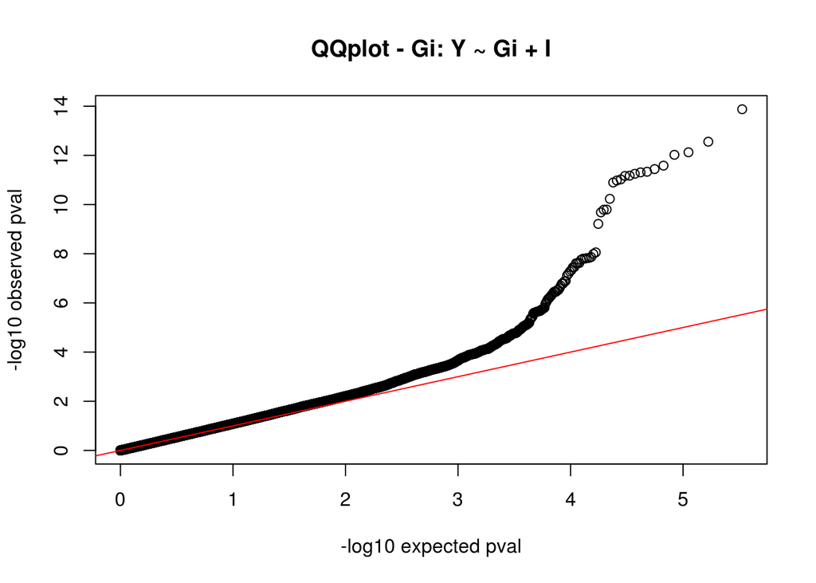

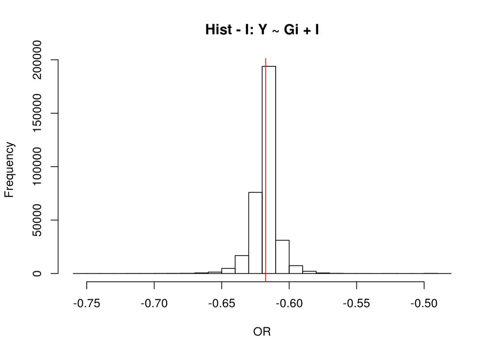

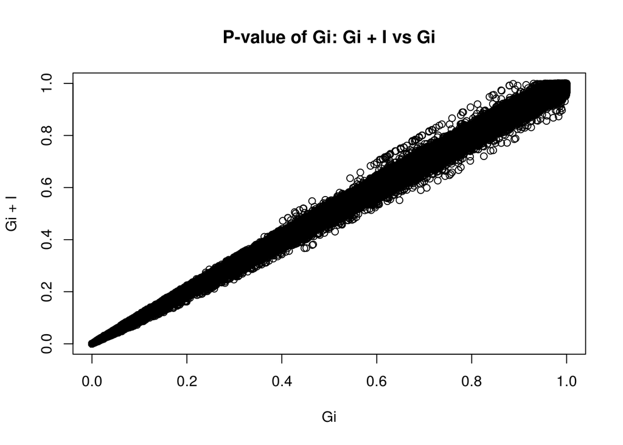

## Cutoff = 0.3

Filename is output-direction_XT_YI/Prins_igf1__wtccc_crohn__wtccc_ctrl/covar_LDpred_p3.0000e-01.txt

|  | intercept.estmate | intercept.std | intercept.pval | prs.estmate | prs.std | prs.pval |
| --- | --- | --- | --- | --- | --- | --- |
| **2** | -0.5361 | 0.0335 | 1.183e-57 | -0.6088 | 0.5167 | 0.2387 |

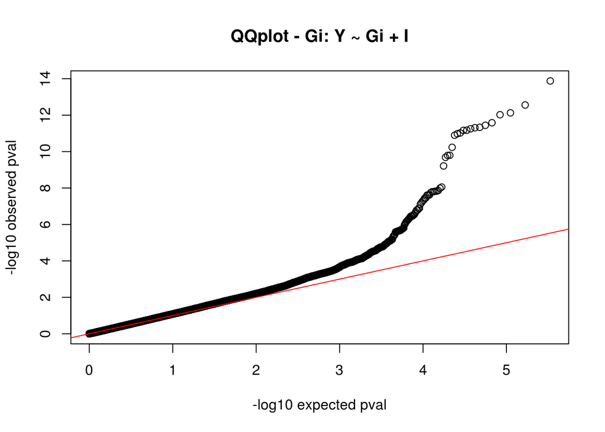

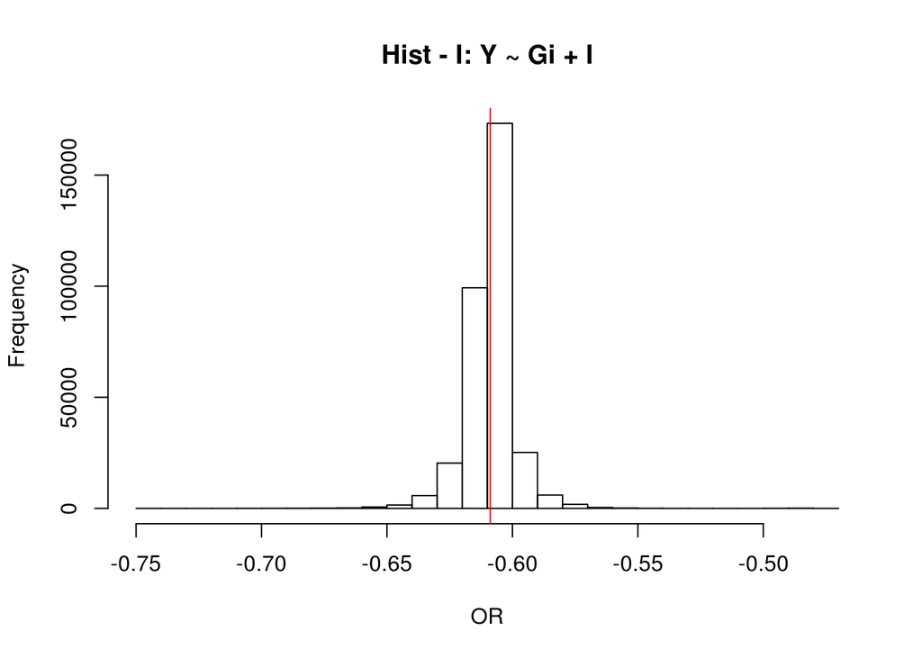

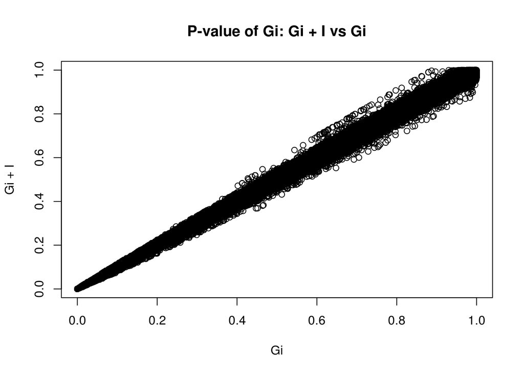

## Cutoff = 0.1

Filename is output-direction_XT_YI/Prins_igf1__wtccc_crohn__wtccc_ctrl/covar_LDpred_p1.0000e-01.txt

|  | intercept.estmate | intercept.std | intercept.pval | prs.estmate | prs.std | prs.pval |
| --- | --- | --- | --- | --- | --- | --- |
| **3** | -0.5346 | 0.03318 | 2.021e-58 | -0.584 | 0.5164 | 0.2581 |

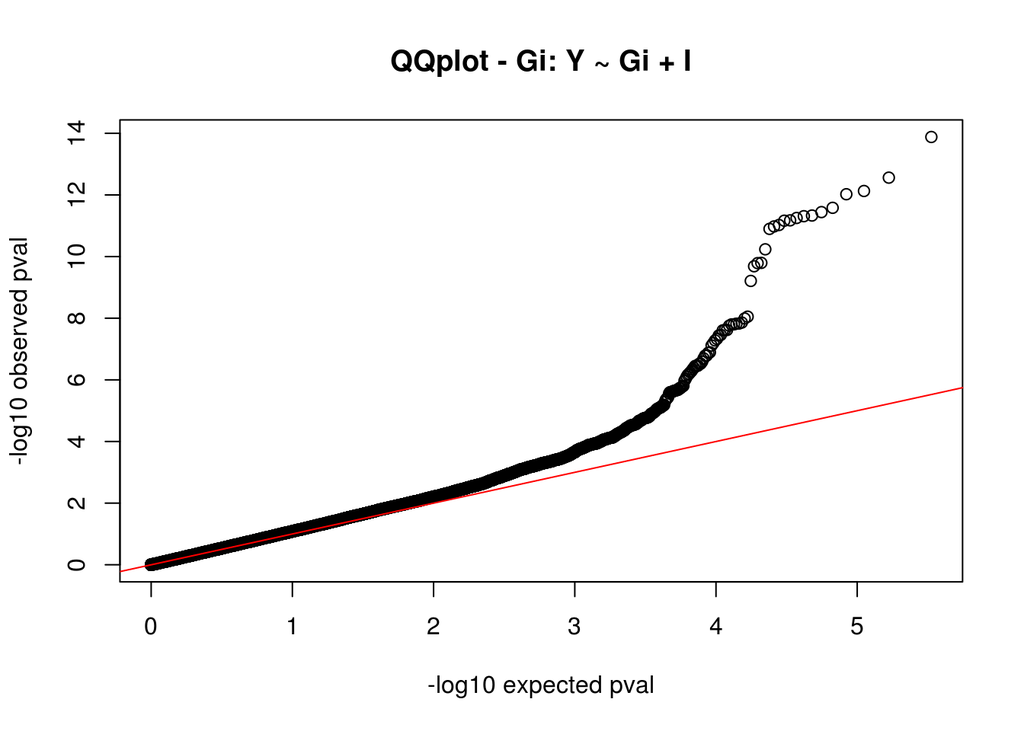

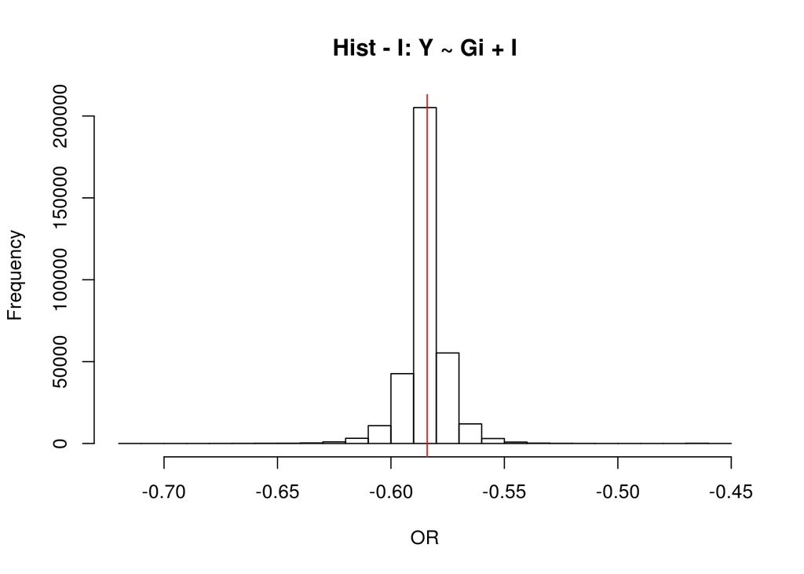

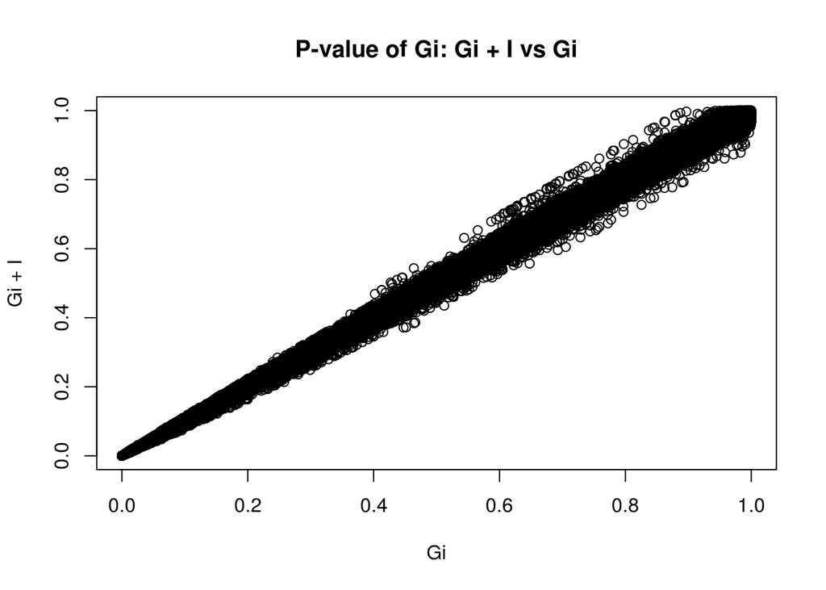

## Cutoff = 0.03

Filename is output-direction_XT_YI/Prins_igf1__wtccc_crohn__wtccc_ctrl/covar_LDpred_p3.0000e-02.txt

|  | intercept.estmate | intercept.std | intercept.pval | prs.estmate | prs.std | prs.pval |
| --- | --- | --- | --- | --- | --- | --- |
| **4** | -0.5301 | 0.03222 | 8.5e-61 | -0.4998 | 0.5137 | 0.3306 |

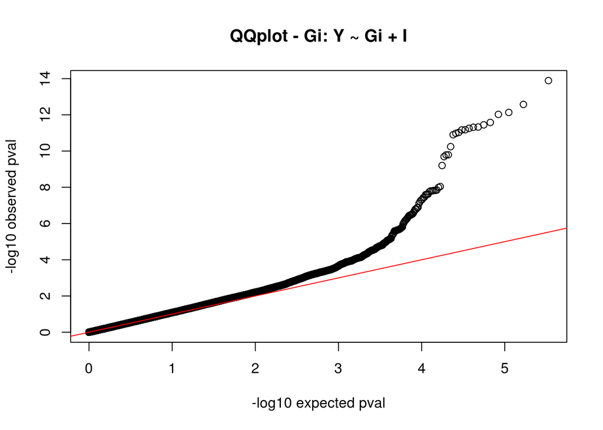

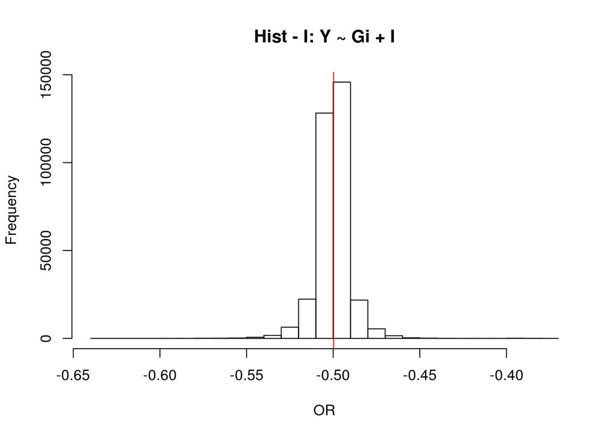

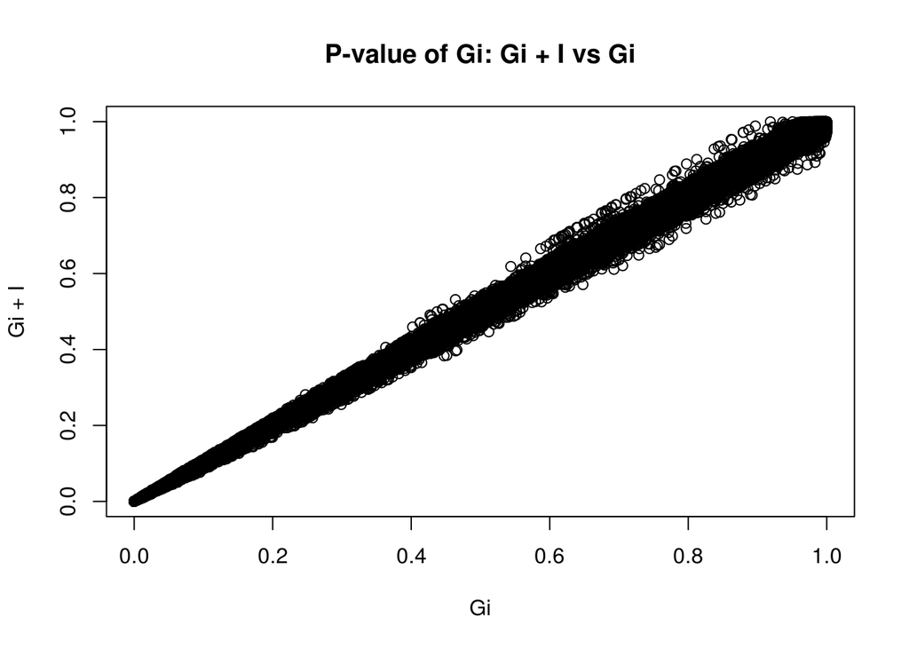

## Cutoff = 0.01

Filename is output-direction_XT_YI/Prins_igf1__wtccc_crohn__wtccc_ctrl/covar_LDpred_p1.0000e-02.txt

|  | intercept.estmate | intercept.std | intercept.pval | prs.estmate | prs.std | prs.pval |
| --- | --- | --- | --- | --- | --- | --- |
| **5** | -0.5237 | 0.03103 | 6.89e-64 | -0.306 | 0.4875 | 0.5303 |

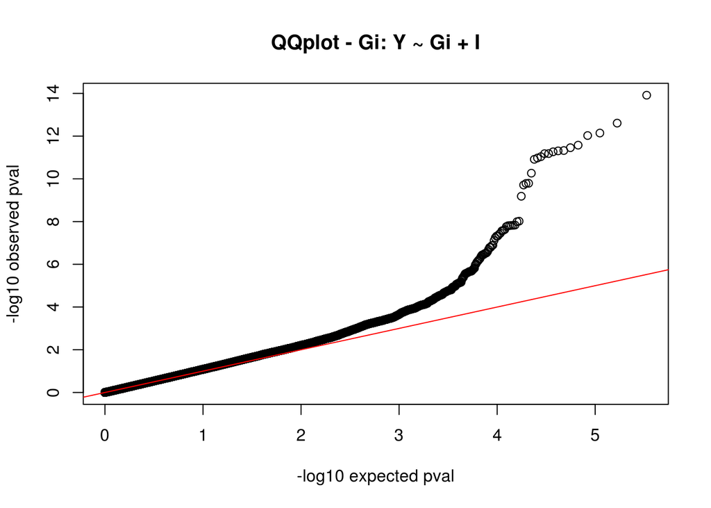

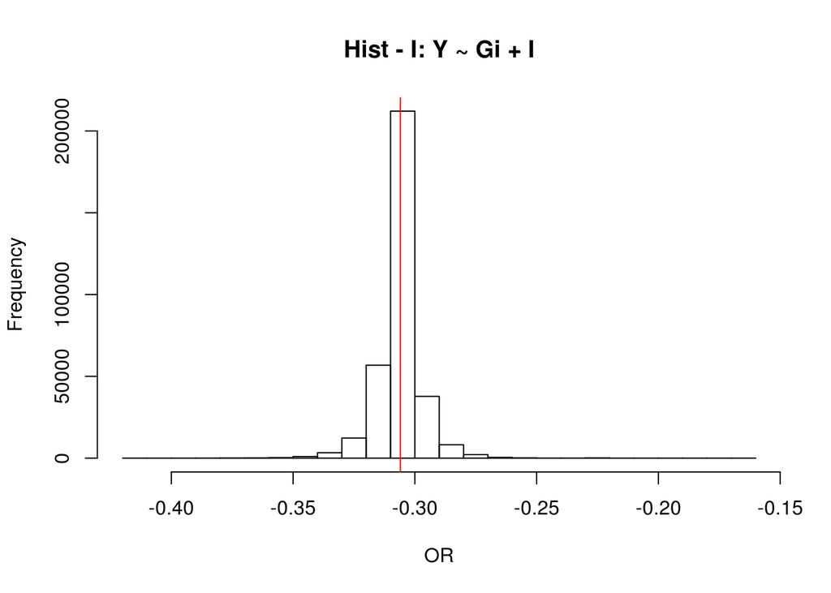

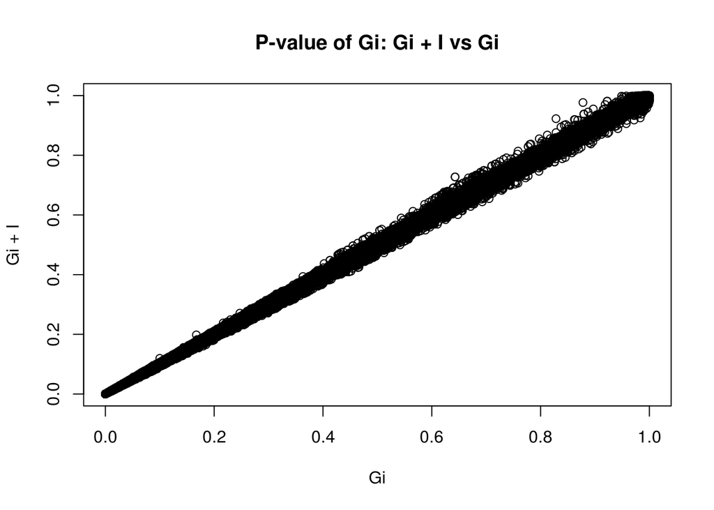

## Cutoff = 0.003

Filename is output-direction_XT_YI/Prins_igf1__wtccc_crohn__wtccc_ctrl/covar_LDpred_p3.0000e-03.txt

|  | intercept.estmate | intercept.std | intercept.pval | prs.estmate | prs.std | prs.pval |
| --- | --- | --- | --- | --- | --- | --- |
| **6** | -0.5227 | 0.0319 | 2.488e-60 | -0.09985 | 0.2948 | 0.7348 |

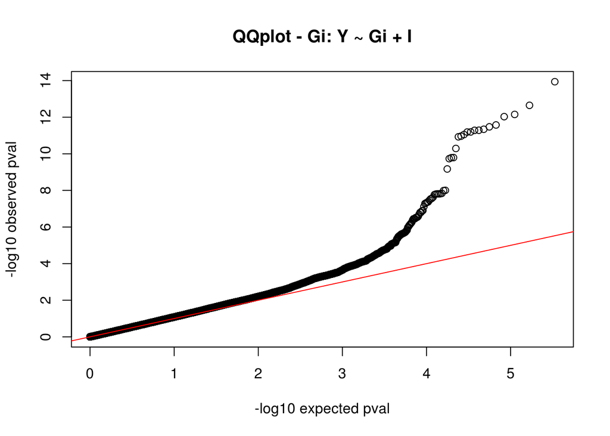

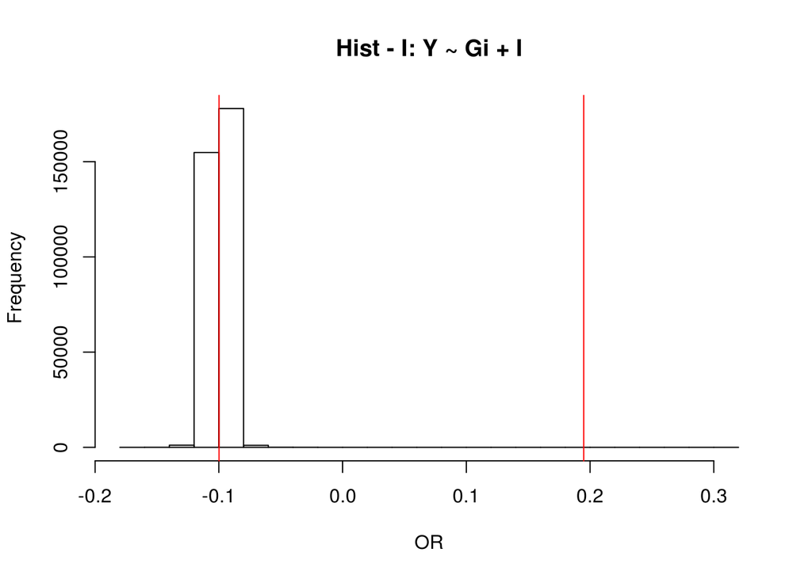

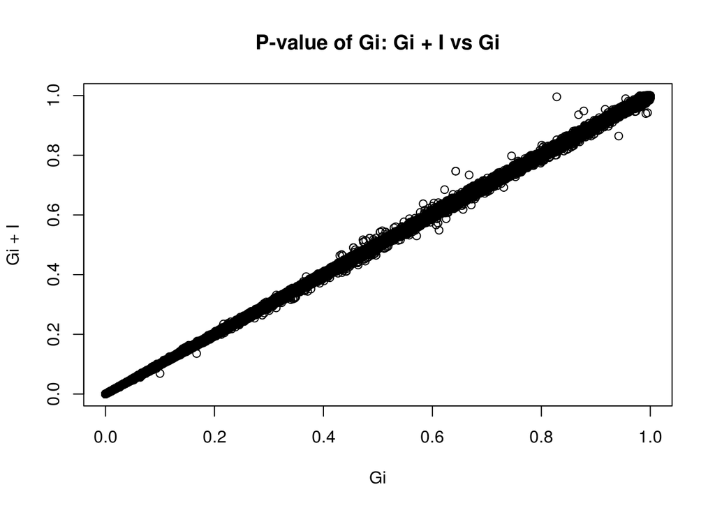

## Cutoff = 0.001

Filename is output-direction_XT_YI/Prins_igf1__wtccc_crohn__wtccc_ctrl/covar_LDpred_p1.0000e-03.txt

|  | intercept.estmate | intercept.std | intercept.pval | prs.estmate | prs.std | prs.pval |
| --- | --- | --- | --- | --- | --- | --- |
| **7** | -0.5267 | 0.03394 | 2.69e-54 | -0.08536 | 0.1777 | 0.6309 |

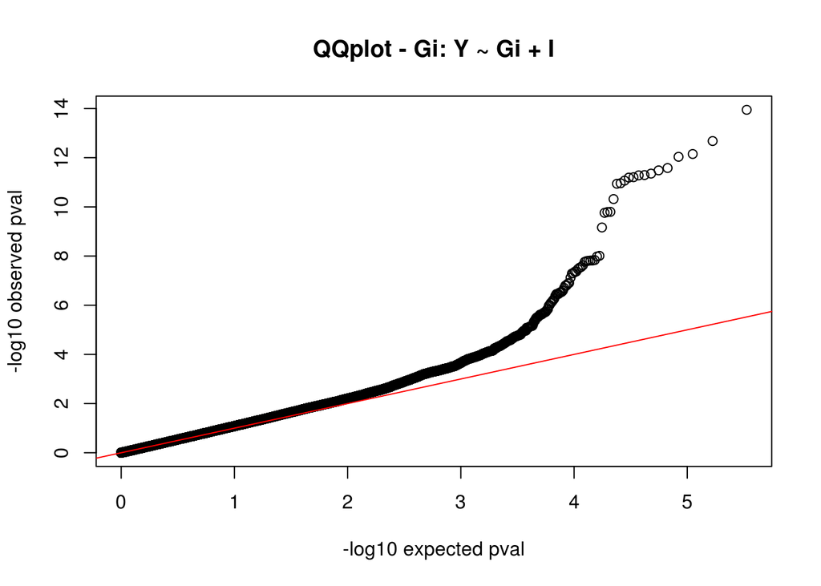

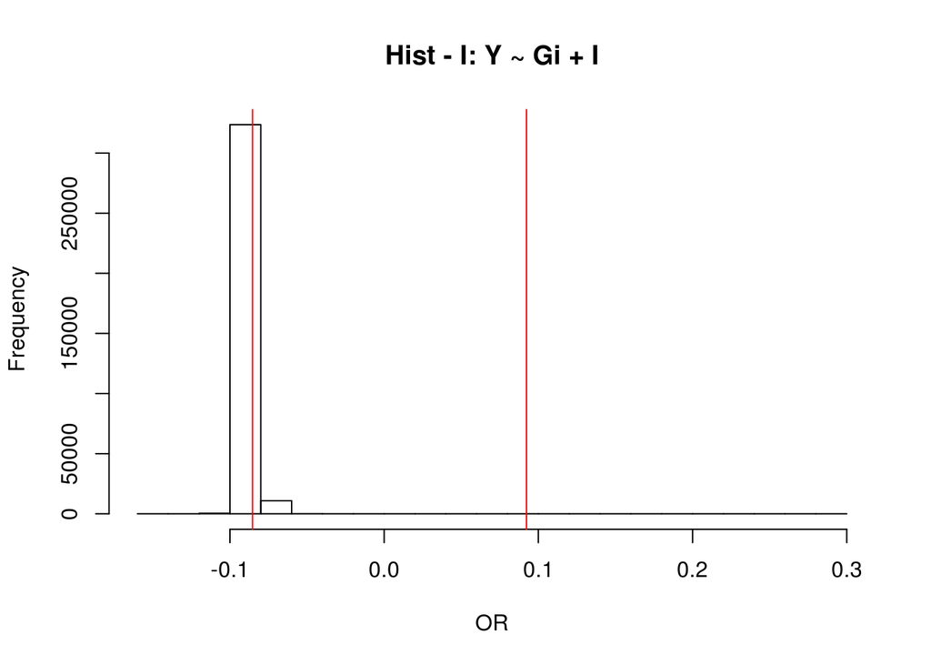

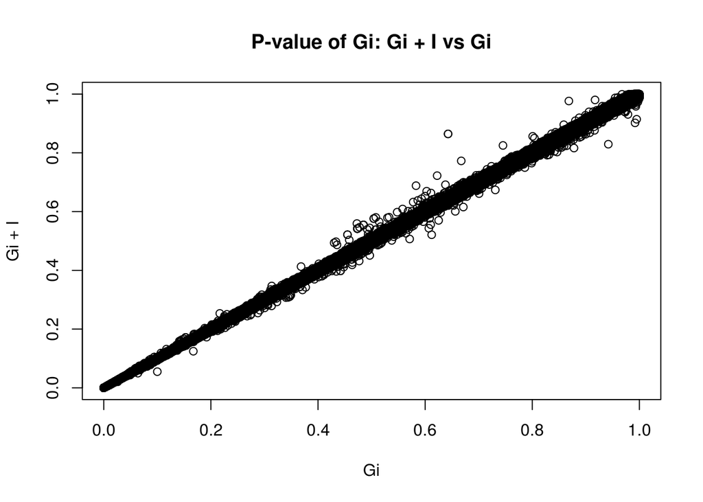

## Cutoff = 0.0003

Filename is output-direction_XT_YI/Prins_igf1__wtccc_crohn__wtccc_ctrl/covar_LDpred_p3.0000e-04.txt

|  | intercept.estmate | intercept.std | intercept.pval | prs.estmate | prs.std | prs.pval |
| --- | --- | --- | --- | --- | --- | --- |
| **8** | -0.5378 | 0.03753 | 1.412e-46 | -0.1437 | 0.1716 | 0.4022 |

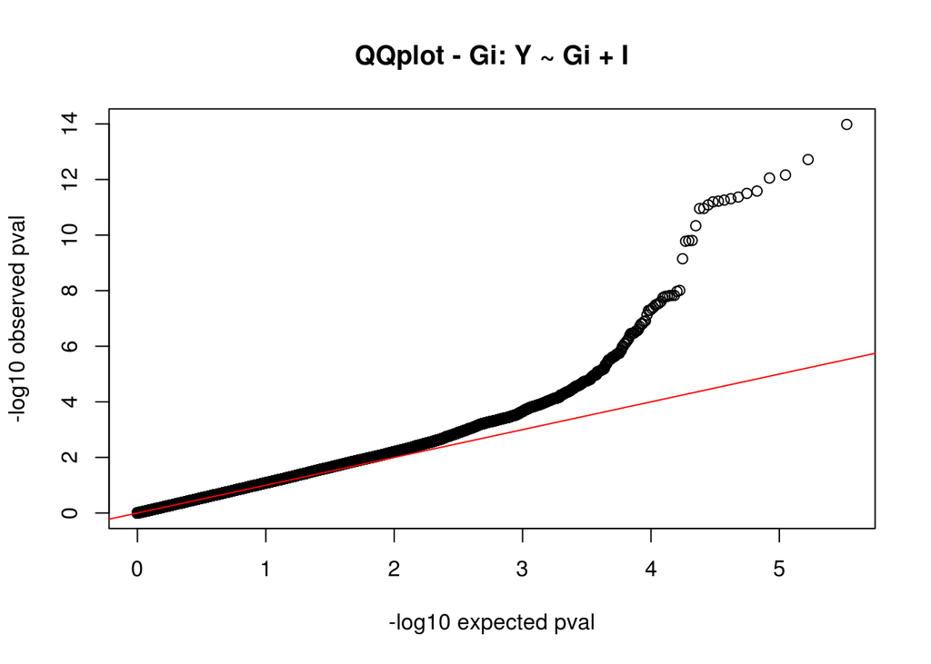

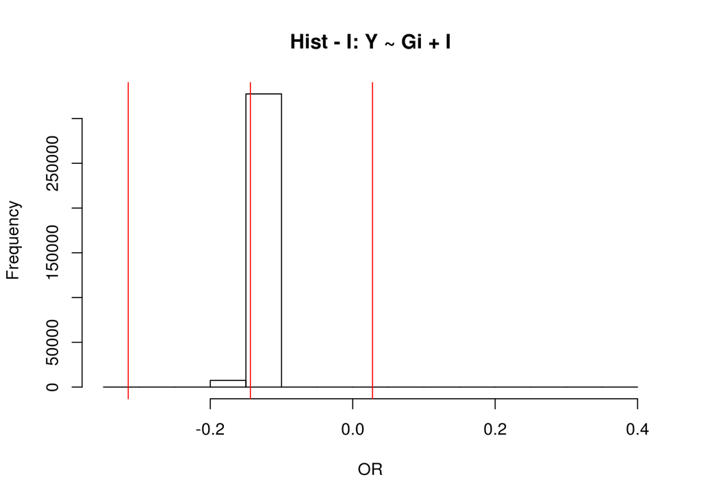

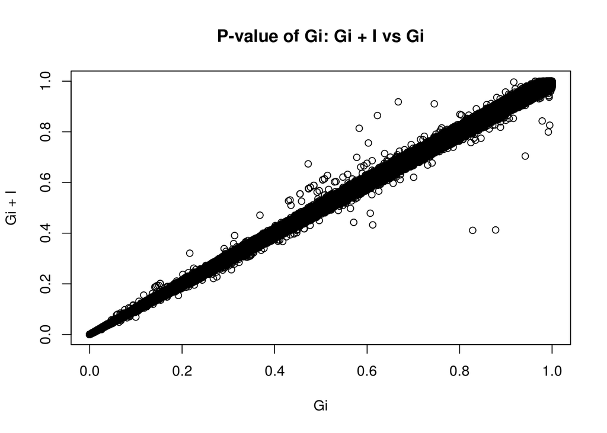

## Cutoff = 0.0001

Filename is output-direction_XT_YI/Prins_igf1__wtccc_crohn__wtccc_ctrl/covar_LDpred_p1.0000e-04.txt

|  | intercept.estmate | intercept.std | intercept.pval | prs.estmate | prs.std | prs.pval |
| --- | --- | --- | --- | --- | --- | --- |
| **9** | -0.5465 | 0.04142 | 9.627e-40 | -0.1911 | 0.1981 | 0.3347 |

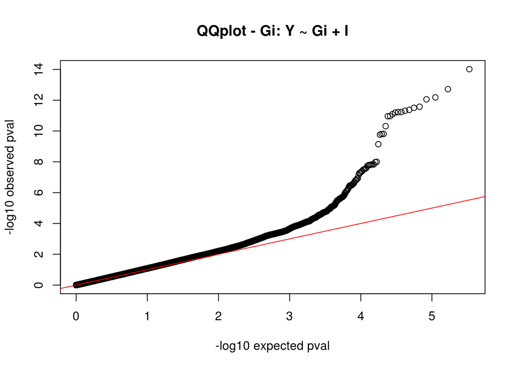

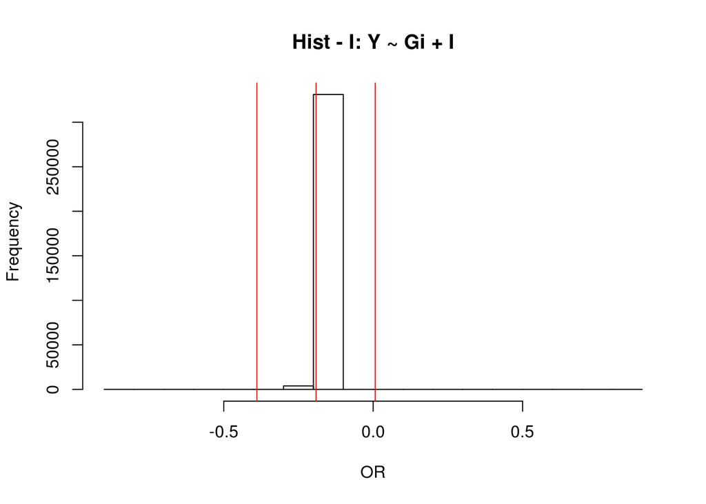

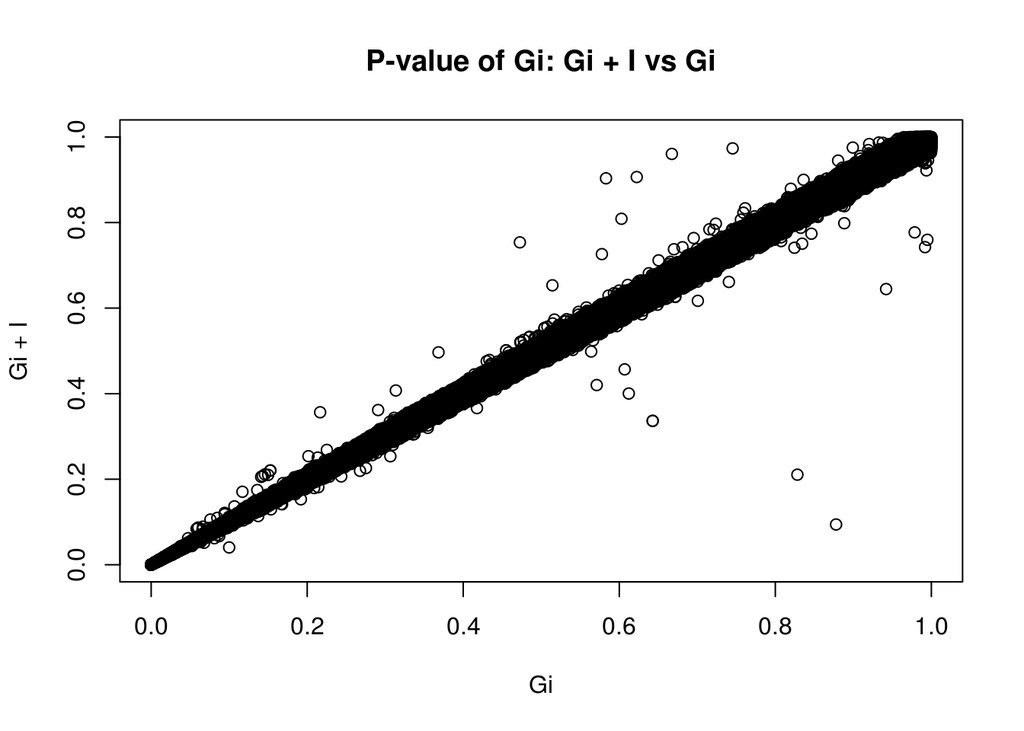